# Homework Part 3 - Ryan Lata

```r
R.version.string
```

```
## [1] "R version 3.4.2 (2017-09-28)"
```

```r
Sys.Date()
```

```
## [1] "2017-11-15"
```

```r
#Reading in data
house <- read.table(file="housing.txt",header=TRUE,as.is=TRUE)
head(house)
```

```
##   PRICE SQFT AGE FEATS NE CUST COR  TAX
## 1  2050 2650  13     7  1    1   0 1639
## 2  2080 2600   *     4  1    1   0 1088
## 3  2150 2664   6     5  1    1   0 1193
## 4  2150 2921   3     6  1    1   0 1635
## 5  1999 2580   4     4  1    1   0 1732
## 6  1900 2580   4     4  1    0   0 1534
```

```r
tail(house)
```

```
##     PRICE SQFT AGE FEATS NE CUST COR TAX
## 112   874 1236   3     4  0    0   0 707
## 113   872 1229   6     3  0    0   0 721
## 114   870 1273   4     4  0    0   0 638
## 115   869 1165   7     4  0    0   0 694
## 116   766 1200   7     4  0    0   1 634
## 117   739  970   4     4  0    0   1 541
```

1. Convert the asterisks in the TAX variable to missing. How many missing values are there for AGE and for TAX?

```r
#Converting asterisks to NAs
house$age.years <- as.numeric(house$AGE)
summary(house$age.years)
```

```
##    Min. 1st Qu.  Median    Mean 3rd Qu.    Max.    NA's
##    1.00    5.75   13.00   14.97   19.25   53.00      49
```

```r
house$tax.value <- as.numeric(house$TAX)
summary(house$tax.value)
```

```
##    Min. 1st Qu.  Median    Mean 3rd Qu.    Max.    NA's
##   223.0   600.0   731.0   793.5   919.0  1765.0      10
```

There are 49 missing values for age, and 10 missing values for taxes

2. Create factors for NE, CUST, and COR. Draw bar charts for each of these factors.

```r
#NE factor
house$NE.factor <- factor(house$NE, levels = 0:1, labels = c("No","Yes"))

#CUST factor
house$CUST.factor <- factor(house$CUST, levels = 0:1, labels = c("No","Yes"))

#COR factor
house$COR.factor <- factor(house$COR, levels = 0:1, labels = c("No","Yes"))
```

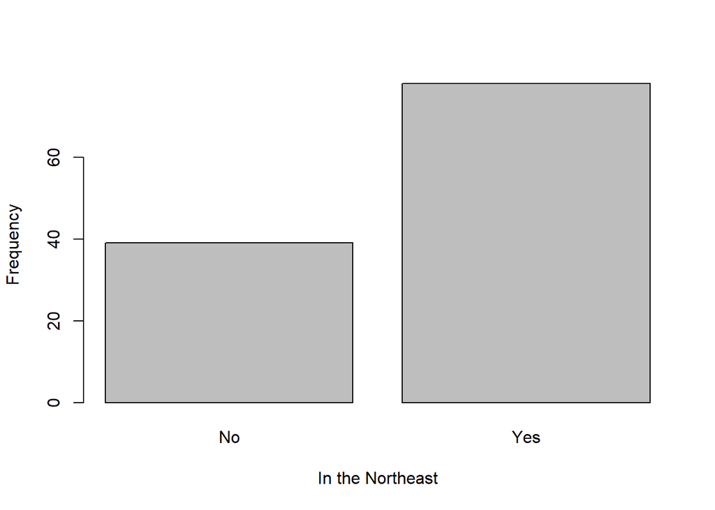

```r
#NE barplot
tabNE <- table(house$NE.factor)
barplot(tabNE, xlab ="In the Northeast", ylab = "Frequency")
```

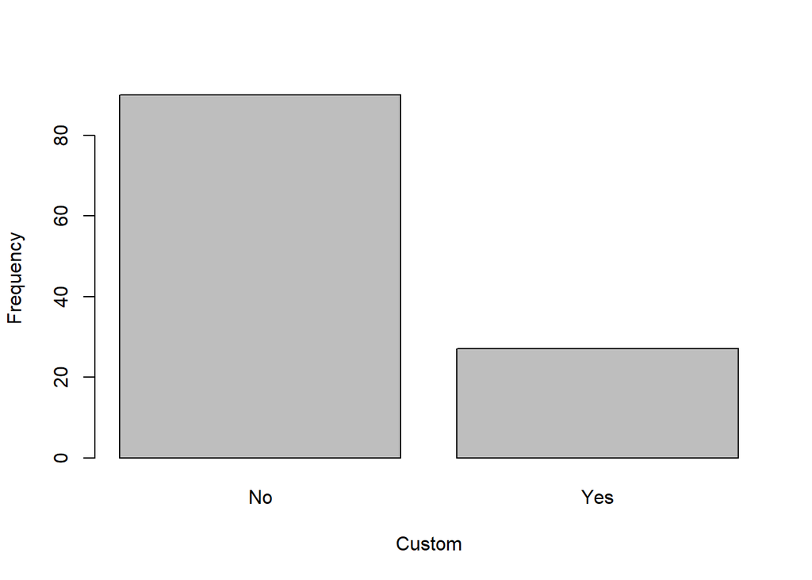

```r
#CUST barplot
tabCUST <- table(house$CUST.factor)
barplot(tabCUST, xlab ="Custom", ylab = "Frequency")
```

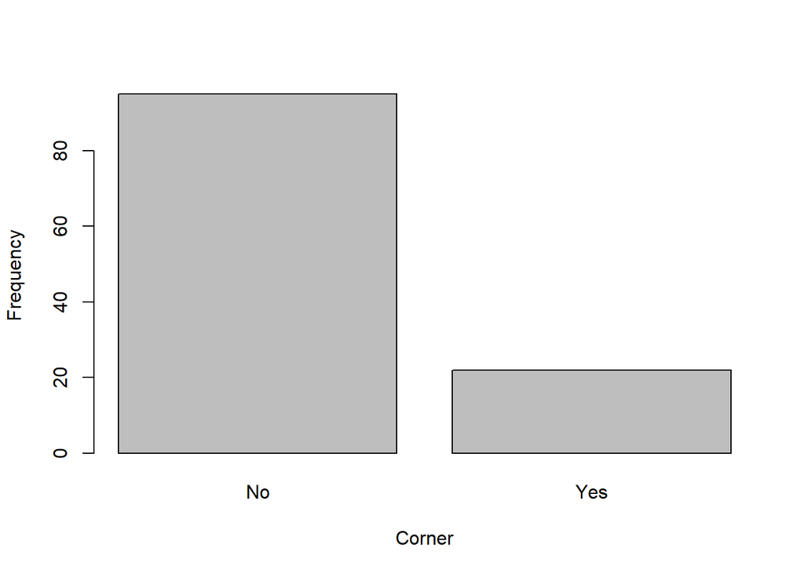

```r
#COR barplot
tablCOR <- table(house$COR.factor)
barplot(tablCOR, xlab="Corner",ylab="Frequency")
```

3. Find the largest house (biggest SQFT) in the data set. Is the largest house also the most expensive house?

```r
#Summary of SQFT
summary(house$SQFT)
```

```
##    Min. 1st Qu.  Median    Mean 3rd Qu.    Max.
##     837    1280    1549    1654    1894    3750
```

```r
#Largest house
house[which.max(house$SQFT), ]
```

```
##    PRICE SQFT AGE FEATS NE CUST COR  TAX age.years tax.value NE.factor
## 79  1295 3750   *     4  0    1   1 1200        NA      1200        No
##    CUST.factor COR.factor
## 79         Yes        Yes
```

```r
#Summary of cost
summary(house$PRICE)
```

```
##    Min. 1st Qu.  Median    Mean 3rd Qu.    Max.
##     540     780     960    1063    1200    2150
```

```r
#Most expensive house
house[which.max(house$PRICE), ]
```

```
##   PRICE SQFT AGE FEATS NE CUST COR  TAX age.years tax.value NE.factor
## 3  2150 2664   6     5  1    1   0 1193         6      1193       Yes
##   CUST.factor COR.factor
## 3         Yes         No
```

The largest house is not the most expensive house

4. Calculate frequency counts for FEATS. Are there any houses with the no features? Are there any houses with every possible feature?

```r
#FEATS frequencies
table(house$FEATS)
```

```
##
##  0  1  2  3  4  5  6  7  8
##  2  7 16 28 43 11  8  1  1
```

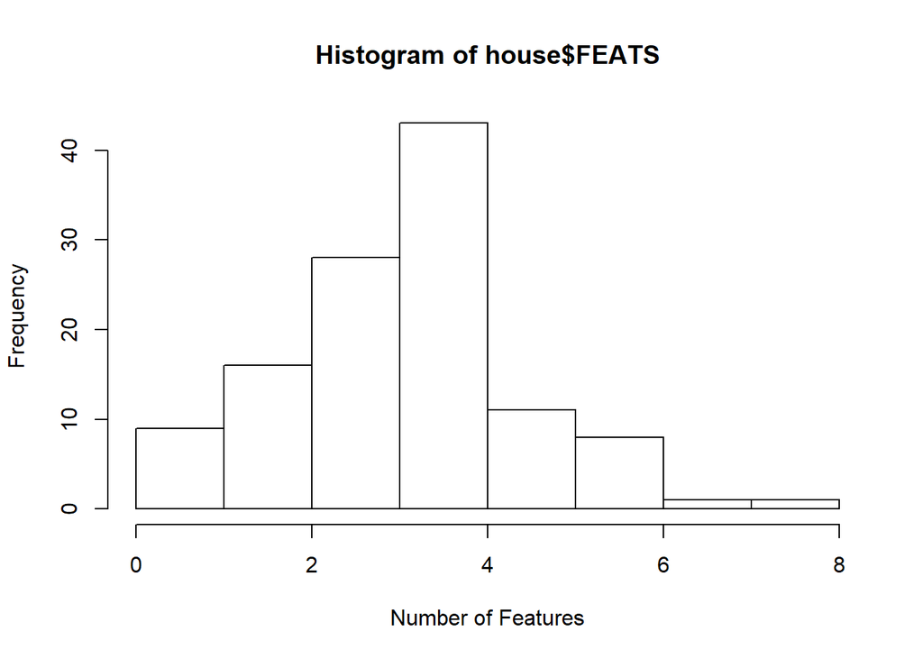

```r
hist(house$FEATS, xlab = "Number of Features", ylab = "Frequency")
```

Two houses have no features No house has every feature (Max is 8, Total possible is 11)

5. Evaluate the relationship between PRICE and SQFT using a scatterplot. Include a smooth curve. Do larger houses tend to cost more?

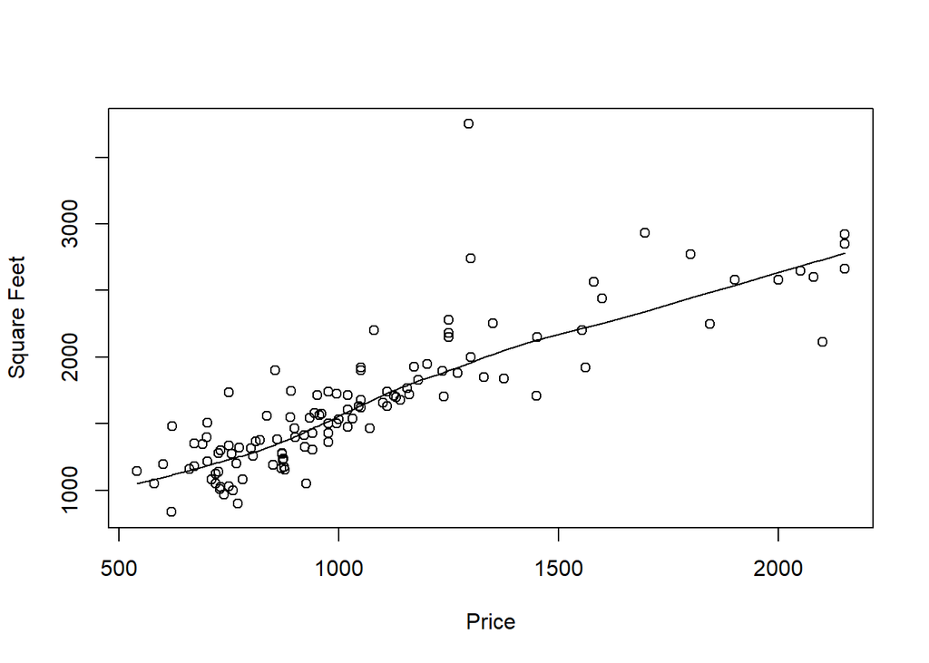

```r
#Price vs Square Feet
plot(house$PRICE,house$SQFT, xlab = "Price", ylab = "Square Feet")
smooth.curve <- lowess(house$PRICE,house$SQFT)
lines(smooth.curve)
```

Yes, larger houses tend to cost more

6. Evaluate the relationship between CUST and PRICE using a boxplot. Calculate the mean price and standard deviation by CUST.

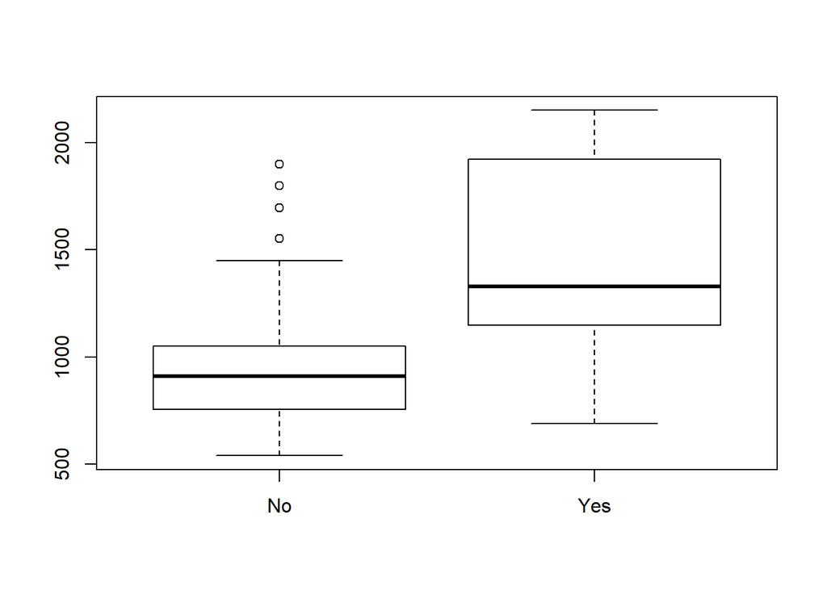

```r
#Boxplot CUST vs PRICE
boxplot(PRICE~CUST.factor, data=house)
```

```r
#Mean
by(house$PRICE,house$CUST.factor,mean,na.rm=TRUE)
```

```
## house$CUST.factor: No
## [1] 947.5222
## --------------------------------------------------------
## house$CUST.factor: Yes
## [1] 1446.778
```

```r
#SD
by(house$PRICE,house$CUST.factor,sd,na.rm=TRUE)
```

```
## house$CUST.factor: No
## [1] 253.6565
## --------------------------------------------------------
## house$CUST.factor: Yes
## [1] 475.7863
```

```r
#Mean and SD
grp.means <- by(house$PRICE,house$CUST.factor,mean,na.rm=TRUE)
grp.stdev <- by(house$PRICE,house$CUST.factor,sd,na.rm=TRUE)
colon <- ": "
plus.minus <- "+/-"
paste(names(grp.means),colon,round(grp.means,1),
      plus.minus,round(grp.stdev,1),sep="")
```

```
## [1] "No: 947.5+/-253.7"   "Yes: 1446.8+/-475.8"
```

7. What is the difference in average prices between northeast houses and other houses? What is the difference in average taxes?

```r
#Mean price by location
by(house$PRICE,house$NE.factor,mean,na.rm=TRUE)
```

```
## house$NE.factor: No
## [1] 972.8205
## --------------------------------------------------------
## house$NE.factor: Yes
## [1] 1107.692
```

```r
price.means <- by(house$PRICE,house$NE.factor,mean,na.rm=TRUE)
#Mean tax by location
by(house$tax.value,house$NE.factor,mean,na.rm=TRUE)
```

```
## house$NE.factor: No
## [1] 708.4444
## --------------------------------------------------------
## house$NE.factor: Yes
## [1] 836.6056
```

```r
tax.means <- by(house$tax.value,house$NE.factor,mean,na.rm=TRUE)
#Average difference taxes
tax.dif <- tax.means[["Yes"]] - tax.means[["No"]]
paste("Difference: ",round(tax.means[["Yes"]],2),"-",round(tax.means[["No"]],2),"=",round(tax.dif,2))
```

```
## [1] "Difference:  836.61 - 708.44 = 128.16"
```

```r
#Average differencec price
price.dif <- price.means[["Yes"]] - price.means[["No"]]
paste("Difference: ",round(price.means[["Yes"]],2),"-",round(price.means[["No"]],2),"=",round(price.dif,2))
```

```
## [1] "Difference:  1107.69 - 972.82 = 134.87"
```

8. Are custombuilt houses more likely to appear on corner lots? Calculate the percentages and compute a relative risk.

```r
house$COR.factor.2 <- factor(house$COR, levels = 0:1, labels = c("Not-Corner","Corner"))
house$CUST.factor.2 <- factor(house$CUST, levels = 0:1, labels = c("Not-Custom","Custom"))

library(epitools)
#Percentages
tb <- table(house$COR.factor.2,house$CUST.factor.2)
round(100*prop.table(tb,margin=2),2)
```

```
##
##              Not-Custom Custom
##   Not-Corner      81.11  81.48
##   Corner          18.89  18.52
```

```r
#Relative risk
riskratio(tb)$measure
```

```
##             risk ratio with 95% C.I.
##              estimate     lower    upper
##   Not-Corner 1.000000        NA       NA
##   Corner     0.981405 0.4181502 2.303372
```

Custom houses are not more likely to appear on corner lots

9. Place all the key results into a Word document, add a bit of commentary, and turn it in.